# IE 582 - Homework - 4

Serhat Arca

December 19, 2018

## 1. Classification Data with Class Imbalance

This dataset classifies people described by a set of attributes as good or bad credit risks.The data has 1000 instances and 20 attributes. The dataset is for classification with a class imbalance problem. The number of a certain class (class 3) is too small compared to the others (Only 63 out of 1000).

http://archive.ics.uci.edu/ml/datasets/Statlog+%28German+Credit+Data%29

### 1.1. Penalized Regression Approaches (PRA)

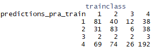

**Figure 1** - PRA Training Data Confusion Matrix.

The accuracies for training and test data are almost identical. An accuracy of around 0.51 is pretty low, which indicates that PRA is not a suitable classifier for this data set. The number of classifications for the 3rd class is very low. There are 63 instances that are labeled as 3rd class in the original data but there are only 15 data that the model classifies as Class 3. This is a result of the class imbalance.

### 1.2. Decision Trees (DT)

Decision trees are used for classification purpose. The parameter that is tuned for this purpose complexity parameter. Caret package is used for 10-fold cross validation.

The result of cross-validation for complexity parameter is found to be 0.01635514.Using the optimum complexity parameter value, a model is constructed based on the training data. The accuracy is calculated by dividing the number of correct classifications to the total number of classifications. The accuracy for the training data is found to be 0.4835479 and the confusion matrix is found as

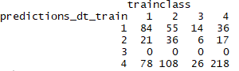

**Figure 3** - DT Training Data Confusion Matrix.

The accuracies for training and test data are almost identical. An accuracy of around 0.48 is pretty low, which indicates that DT is not a suitable classifier for this data set. The accuracy for DT is lower, compared to PRA. The error for test data is higher, compared to the training data, which is the expected result.

### 1.3. Support Vector Machines (SVM)

The parameters that are tuned for SVM are kernel type and the kernel parameters. Two types of kernels, namely polynomial and Gaussian, are used. Caret package is used for 10-fold cross validation.

For Gaussian kernel, the result of cross-validation for sigma is found to be 0.01632459.Using the optimum sigma value, a model is constructed based on the training data.  
The accuracy for the training data is found to be 0.6351931 and the confusion matrix is found as

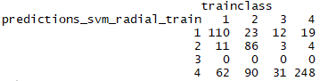

**Figure 5** - SVM Gaussian Kernel Training Data Confusion Matrix.

The accuracy for the test data is found to be 0.5233333 and the confusion matrix is found as

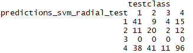

**Figure 6** - SVM Gaussian Kernel Test Data Confusion Matrix.

The accuracy for training data is significantly higher than that of the test data. This might indicate some overfitting. The accuracy for SVM with radial kernel is higher, compared to PRA and DT. This indicates that SVM with radial kernel is more suitable for classification with this data.

For polynomial kernel, the result of cross-validation for degree parameter and scale are found to be 3 and 0.01.Using the optimum degree parameter value, a model is constructed based on the training data.

The accuracy for the training data with polynomial kernel is found to be 0.658083 and the confusion matrix is found as

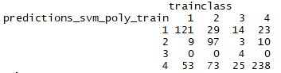

**Figure 7** - SVM Polynomial Kernel Training Data Confusion Matrix.

The accuracy for the test data is found to be 0.5133333 and the confusion matrix is found as

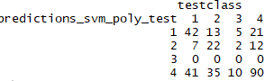

**Figure 8** - SVM Polynomial Kernel Test Data Confusion Matrix.

### 1.4. Random Forest (RF)

The parameter that is tuned for RF is m. Caret package is used for 10-fold cross validation.

The accuracy for training data is significantly higher than that of the test data. This might indicate some overfitting. The training accuracy for RF is higher, compared to PRA, DT and SVM.On the other hand, the test accuracy for RF is pretty low, which might indicate that RF is not very suitable for classification with this data. A method such as bootstrapping was not used, which might be a reason for the large difference between the test and training errors.

### 1.5. Stochastic Gradient Boosting (SGB)

The parameters that are tuned for SGB are depth, learning rate and number of tress. Caret package is used for 10-fold cross validation.

The results of cross-validation for depth and learning rate are found to be 3 and 0.4 respectively.Using the optimum values of the parameters, a model is constructed based on the training data.

The accuracy for the training data is found to be 0.8268956 and the confusion matrix is found as

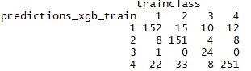

**Figure 11** - SGB Training Data Confusion Matrix.

The accuracy for training data is significantly higher than that of the test data. This might indicate some overfitting. The training accuracy for SGB is higher, compared to PRA, DT, SVM and RF.In this sense, SGB is more suitable for classification with this data compared to other methods.In addition to these, SGB seems to be the best method to overcome the class imbalance problem with 24 correct match in training data.

## 2. Regression Data

The PD database consists of training and test files. The data consists of multiple types of sound recordings (26 voice samples including sustained vowels, numbers, words and short sentences) from 20 PWP (6 female, 14 male) and 20 healthy individuals (10 female, 10 male) who appealed at the Department of Neurology in Cerrahpasa Faculty of Medicine, Istanbul University. A group of 26 linear and time frequency based features are extracted from each voice sample. UPDRS ((Unified Parkinson™s Disease Rating Scale) score of each patient which is determined by expert physician is taken as the output of the data.

http://archive.ics.uci.edu/ml/datasets/Parkinson+Speech+Dataset+with++Multiple+Types+of+Sound+Recordings

### 2.1. Penalized Regression Approaches (PRA)

The RMSE for training and test data are found to be 5.50 and 5.34 for test and training data respectively. The error from the training data is smaller than that of the test data. The mean values of the output for test and train data are 12.87 and 13.04 respectively. Considering these values, a RMSE around 5.5 seems quite high and it can be concluded that PRA is not very suitable for regression of this dataset

### 2.2. Decision Trees (DT)

The parameter that is tuned for this purpose complexity parameter. Caret package is used for 10-fold cross validation.

The result of cross-validation for complexity parameter is found to be 0.04448864.

### 2.3. Support Vector Machines (SVM)

The parameters that are tuned for SVM are kernel type and the kernel parameters. Two types of kernels, namely polynomial and Gaussian, are used. Caret package is used for 10-fold cross validation.

For Gaussian kernel, the result of cross-validation for sigma is found to be 0.05111867.Using the optimum sigma value, a model is constructed based on the training data.  
The RMSE for the training and test data are found to be 3.89 and 3.65 respectively. Comparing these values with the average of the output (around 13), an RMSE around 3.7 seems reasonable but it can be concluded that SVM with Gaussian kernel is not very suitable for regression of this dataset.

For polynomial kernel, the result of cross-validation for degree parameter and scale are found to be 3 and 0.01.Using the optimum degree parameter value, a model is constructed based on the training data.

The RMSE for the training and test data are found to be 4.71 and 4.5 respectively. Comparing these values with the SVM with Gaussian kernel, it can be seen that Gaussian kernel results in better results. It can also be concluded that SVM with polynomial kernel is not very suitable for regression of this dataset.